# Tutorial en R

#### Ejemplo distribución t-Student

La distribución t es una distribución de probabilidad que estima el valor de la media de una muestra pequeña extraída de una población que sigue una distribución normal y de la cual no conocemos su desviación típica.

P(T >= 2.2010) con 11 grados de libertad

```r
pt(2.2010,11,lower.tail = FALSE)
```

```
## [1] 0.02499935
```

```r
dt(2,14)##Probabilidad de 2 con 14 grados de libertad
```

```
## [1] 0.05950834
```

```r
rt(2,14,20)#Dos valores con 14 grados de libertad
```

```
## [1] 15.91298 21.41859
```

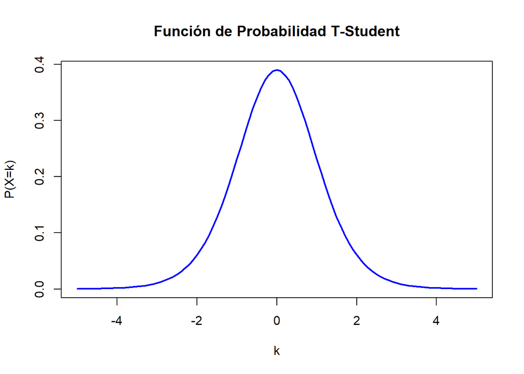

```r
x=seq(-5,5,by=0.01)
curve(dt(x,11),xlim=c(-5,5),col="blue",lwd=2,xlab="k",ylab="P(X=k)",main="Función de Probabilidad T-Student")
```

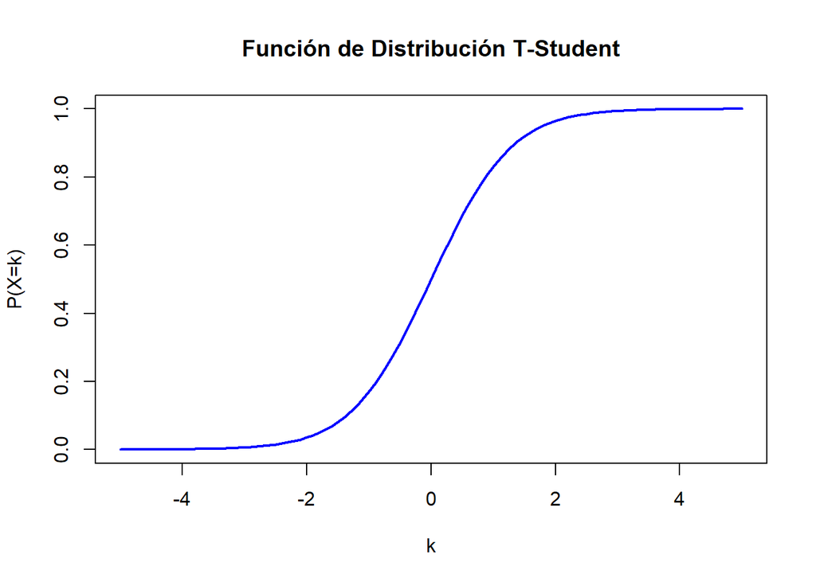

```r
curve(pt(x,11),xlim=c(-5,5),col="blue",lwd=2,xlab="k",ylab="P(X=k)",main="Función de Distribución T-Student")
```

### Referencias

- [Distribuciones de Probabilidad en R](http://estadistica-dma.ulpgc.es/cursoR4ULPGC/10-distribProbabilidad.html#distribuciones_de_probabilidad_en_r)
- [R para principiantes](https://cran.r-project.org/doc/contrib/rdebuts_es.pdf)
- [Tipos de Objetos](https://fhernanb.github.io/Manual-de-R/objetos.html)
- [Operaciones con Matrices](https://rpubs.com/Cesar_AHN/operaciones_con_matrices_multiplicacion_determinante_inversa_factorizacion_descomposicion_grafica)
- [Análisis epxloratorio y visualización de Datos con R](http://www.fcharte.com/libros/ExploraVisualizaConR-Fcharte.pdf)
- [Exploración de datos en R](https://bookdown.org/matiasandina/R-intro/exploracion-de-datos.html)
- [Visualización de datos en R](https://es.r4ds.hadley.nz/visualizaci%C3%B3n-de-datos.html)
- [Análisis exploratorio de datos en R](https://es.r4ds.hadley.nz/an%C3%A1lisis-exploratorio-de-datos-eda.html)
- [Importar (y exportar) datos en R](https://www.uv.es/pjperez/curso_R/tt_3_cargar_datos_v4.html#csv)
- [Importación de datos en R (Hadley)](https://es.r4ds.hadley.nz/importaci%C3%B3n-de-datos.html)
- [Cómo importar datos en R utilizando técnicas muy simples)](https://conceptosclaros.com/importar-datos-r/#El_roadmap_de_los_datos_brutos_a_informacion)